# Visualization for County crime against Population and Staffing

Shivani, William, Chaitra

11/6/2017

## Shivani - Scatter plot for Crime in County’s of Nebraska against Population of the County

### Load the Required Libraries

```r
getwd()
```

```
## [1] "/Users/WillieWetz/Documents/GitHub/Data-Rangers/Deliverables/R_Plot_Deliverable/Rmd - Files"
```

```r
setwd("/Users/WillieWetz/Documents/GitHub/Data-Rangers/Deliverables/R_Plot_Deliverable")
library(ggplot2)
library(ggrepel)
```

### Load the dataset

```r
county_crime <- read.csv('County_crime_and_population_combined.csv')
lawCrime <- read.csv('lawStaff_vs_Crime.csv')
```

### Create a subset for counties with comparatively low population

```r
county_crime_with_low_population <- county_crime[county_crime$Population <= 10000 & county_crime$Population > 100,]
```

### Plot the scatter plot for the county’s in the above subset

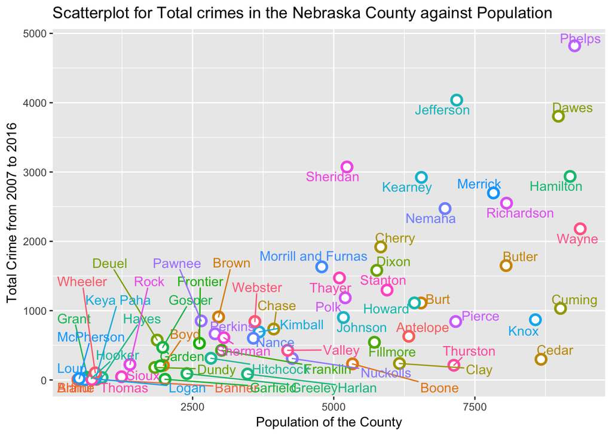

```r
p <- ggplot(county_crime_with_low_population, aes(Population, Total, color = County))

p + geom_point(shape=21, fill="White", size=3,stroke=1.5) + theme(legend.position = "none") + geom_text_repel(aes(label = County)) + xlab("Population of the County") + ylab("Total Crime from 2007 to 2016") + ggtitle("Scatterplot for Total crimes in the Nebraska County against Population")
```

### Final Plot with proper title and axis label

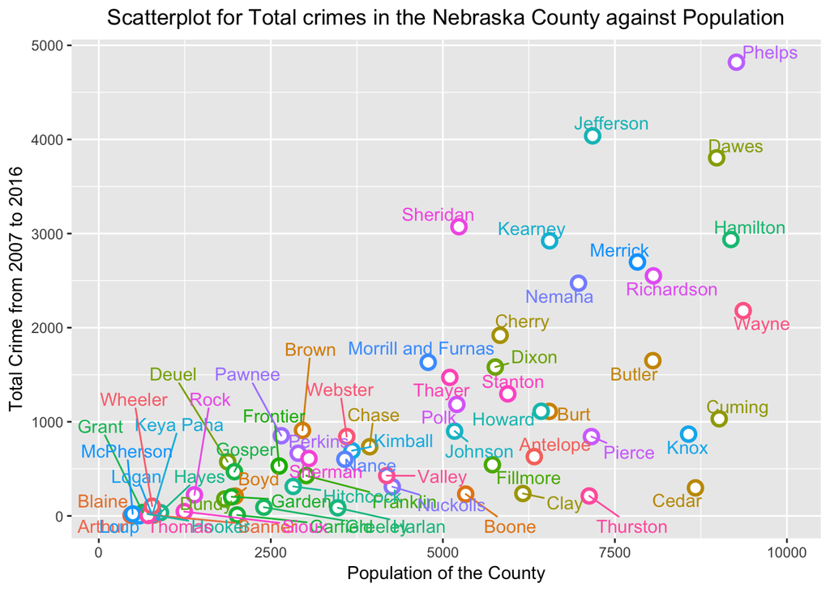

```r
p + geom_point(shape=21, fill="White", size=3,stroke=1.5) + theme(legend.position = "none") + geom_text_repel(aes(label = County)) + xlab("Population of the County") + ylab("Total Crime from 2007 to 2016") + ggtitle("Scatterplot for Total crimes in the Nebraska County against Population") + theme(plot.title = element_text(hjust = 0.5)) + scale_x_continuous(limits = c(100, 10000))
```

> Using a smaller set of the data set gives more specific details from the visualization perspective and hence it was better to group a set of Counties and visualize crime data for that particular group.

## Will - Mapping Law Enforcement Coverage

### Data Preparation

```r
lawCrime <- read.csv('lawStaff_vs_Crime.csv')

# Replace null values with 0, from inconsistent data cleaning
columnsToReplace <- lawCrime[,c("us_so_ft", "us_so_pt", "num_res_so",
                                "us_c_ft", "us_c_pt")]
columnsToReplace[is.na(columnsToReplace)] <- 0
lawCrime[,c("us_so_ft", "us_so_pt", "num_res_so",
            "us_c_ft", "us_c_pt")] <- columnsToReplace

# Create a total full time officer column,
# combining male and female records
lawCrime$total_so <- (lawCrime$ft_so_m + lawCrime$ft_so_f)
# Same for full time civilians
lawCrime$total_c <- lawCrime$ft_c_m + lawCrime$ft_c_f

################
### Map Prep ###
################

# Mapping county zip codes to names
postalCodes <- read.csv('us_postal_codes.csv')
colnames(postalCodes)[5] <- "county"

# Just keep zip codes and county names, and states
postalCodes <- postalCodes[,c(-2,-4,-6,-7,-8)]

# Rows in dataset matching counties in lawCrime and located in NE
indexes <- which(postalCodes$State == 'Nebraska' & postalCodes$county %in% lawCrime$county) #& ])
# Keep only matching rows in the zipcode file
postalCodes <- postalCodes[indexes,]
# Keep only one zip for each County
postalCodes <- postalCodes[!duplicated(postalCodes$county),]


# Create a new dataframe merging LawCrime with county zip codes
lawCrimeMapping <- merge(lawCrime, postalCodes, by = "county", type = "inner")

# Remove state and department columns
lawCrimeMapping <- lawCrimeMapping[,-c(21, 3)]


#!!!!! Map only 2016 data !!!!!#
lawCrimeMapping <- lawCrimeMapping[lawCrimeMapping$year == 2016,]
# Aggregate a number of columns in the event you want to map different things
lawCrimeMapping$county <- as.character(lawCrimeMapping$county)

lawCrimeMapping$pop_covered <- as.numeric(lawCrimeMapping$pop_covered)

lawCrimeMapping <- aggregate(lawCrimeMapping[,c(3,4,5,6,7,8,9,10,12,13,14,17,18)],
                             by=list(county=lawCrimeMapping$county),
                             FUN=sum)
```

### Mapping the Data

> See “lawStaff_vs_Crime_Plot” R script

### Looking at Number of Sworn Officers by County

> Pretty interesting to see there are many counties which have no police department, our policing data does not reflect how resources are spread out for each one amongst neighboring counties. Generally, there is one police department per county with 1 exception. In the middle of the state, we see that the cluster of departments are responsible for patrolling the entire North to South region of the state.

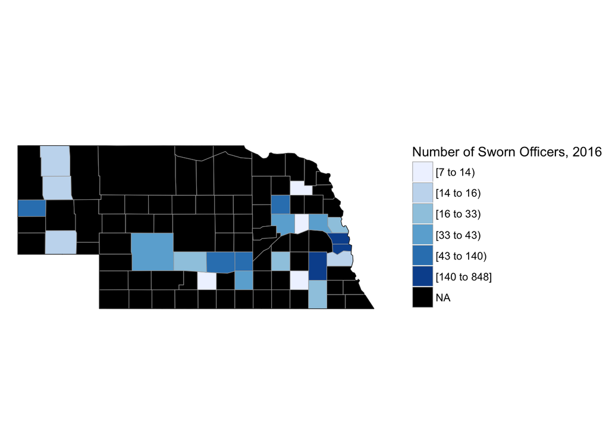

### Population covered by County

> While we mapped by county, each county represents a department. Here we can see the general population densities of Nebraska, as well as the additional burden placed on those central agencies - as they have a relatively high amount of population to cover given the size of the geographic area they operate in.

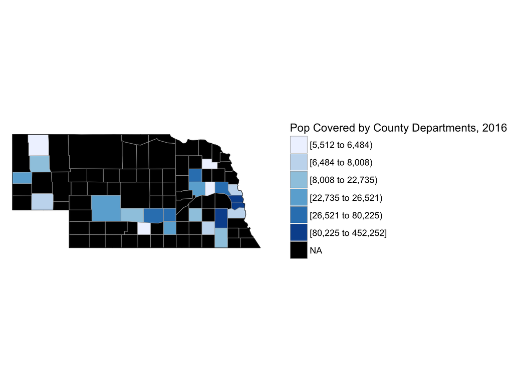

```r
county_mapPop
```

### SO per 1000 People by County

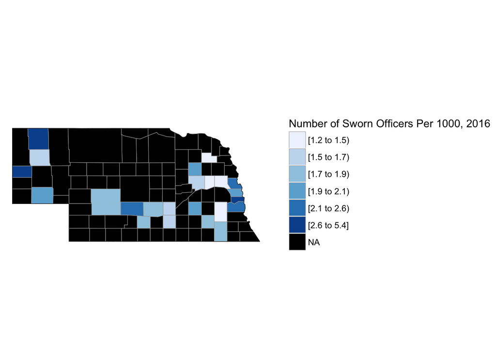

### Annual SO Hiring Trends by Gender

> Hiring trends appear consistent statewide by gender, although only 5-10 female officers are being hired or leaving each year. Due to the relative involatile nature of this visualization, I’m not sure it’s meaningful in our research.

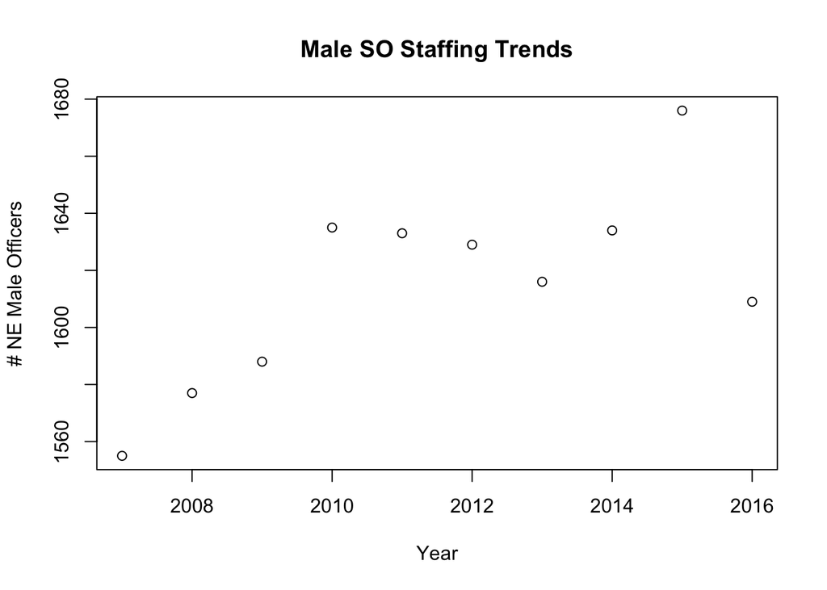

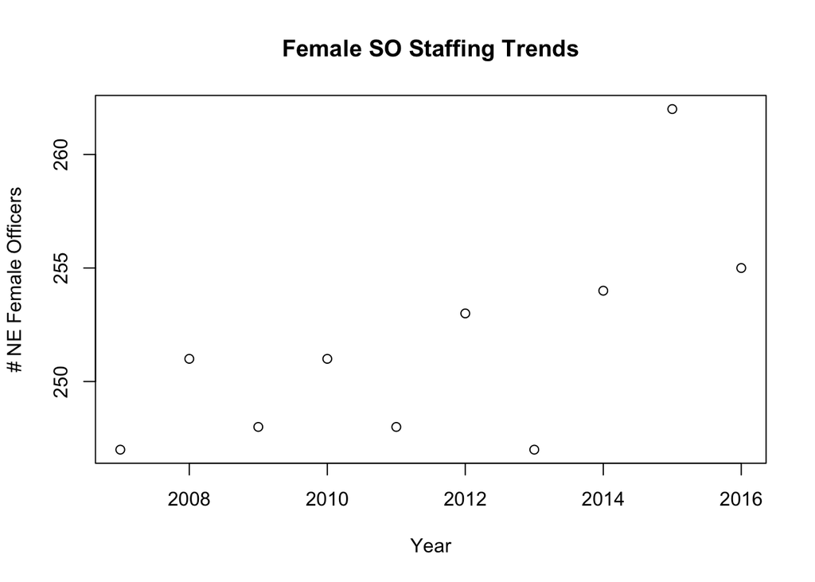

## Chaitra - Economic Indexes vs. Crime Categories

[figure not shown]

[figure not shown]

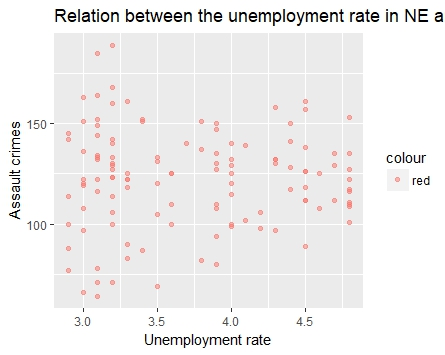

“plot for crimes resulting from assault”

### Data Description

> The unemployment data in Nebraska is collected from 2007-2016 along with the types of crimes committed in those paticular years. Here, we are analysing the relation between the unemployment rate and the the types of crimes committed. This analysis will help us identify patterns in our datasets.

### Relation between the unemeployment rate in Nebraska and the crimes resulting from simple assault

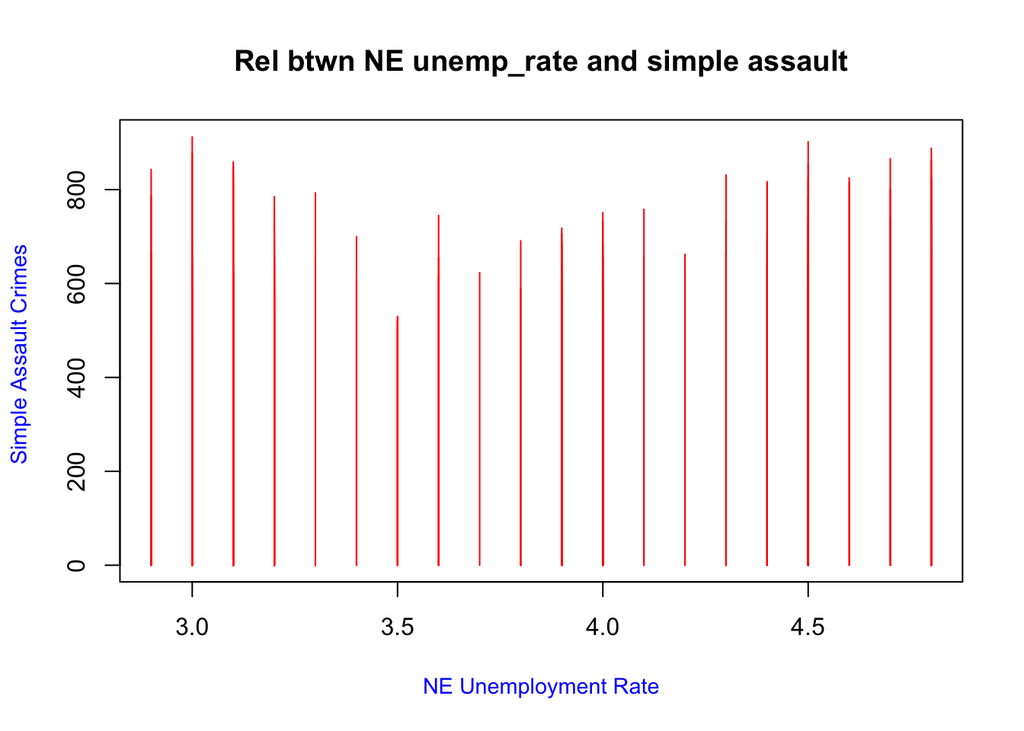

### Relation between the unemeployment rate in Nebraska and drug abuse related crimes

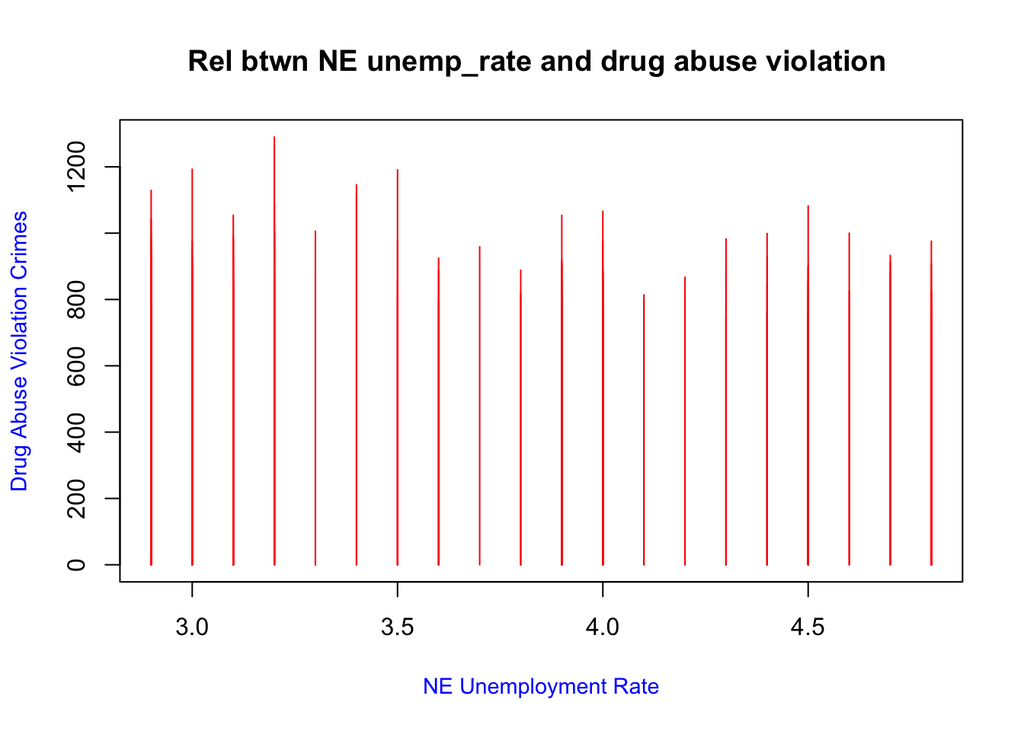

### Relation between the unemeployment rate in Nebraska and curfew related crimes

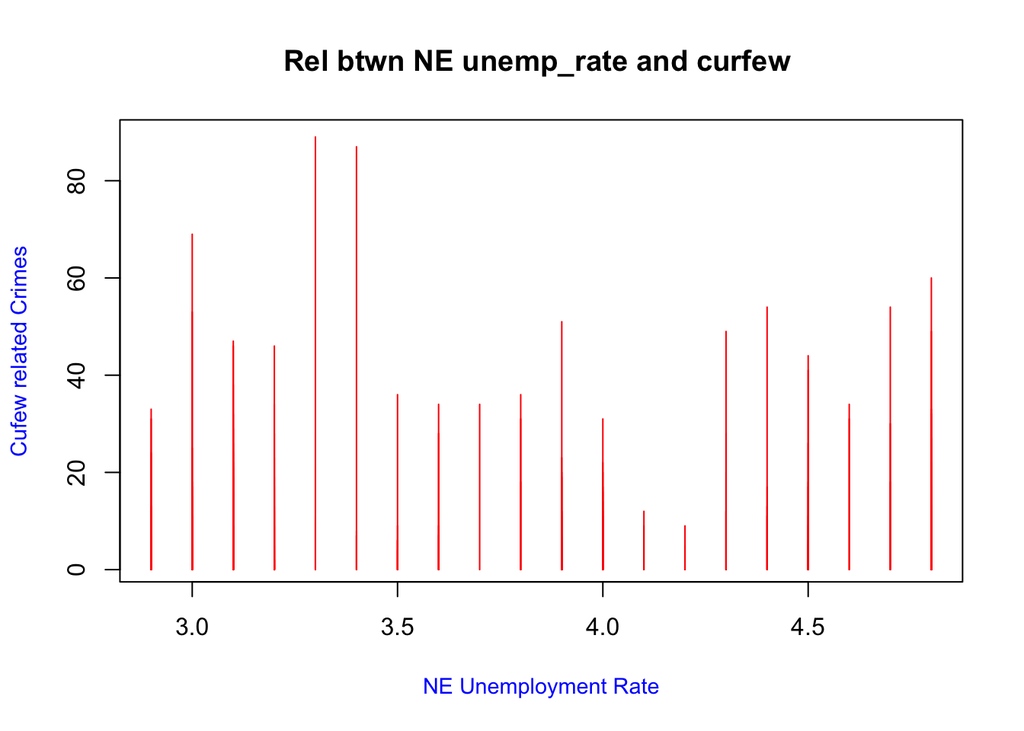